# Text Mining Project

2024-03-27

**Introduction and motivations**

The main of this project differ a bit with the goal of Text Mining. While TM tries to describe a text without reading it and tell a story. Because of my begginer status, I will analyse a story I am familiar with, as a first approach to TM , and in a future, go deeper with my new Text Mining skills.

Now, let’s start analyzing Harry Potter!

**Libraries and Github used in this project**

First, we have to install this package in our R because there is another harrypotter package in R but will not work using install.packages().

```r
remotes::install_github("bradleyboehmke/harrypotter", force = TRUE)
library(tidyverse)
```

```r
library(tidytext)
library(harrypotter)
library(ggplot2)
library(ggwordcloud)
library(RColorBrewer)
library(forcats)
library(widyr)
library(ggraph)
```

First, we need to concatenate the books of Harry Potter.

```r
hp_books <- c(
  "philosophers_stone",
  "chamber_of_secrets",
  "prisoner_of_azkaban",
  "goblet_of_fire",
  "order_of_the_phoenix",
  "half_blood_prince",
  "deathly_hallows"
)
```

Now, we tokenize them and finally we have 3 variables(book, chapter and word), which we essentially need it to develop and perform them later in order to create different analysis.

```r
# combine books into a list
hp_words <- list(
  philosophers_stone,
  chamber_of_secrets,
  prisoner_of_azkaban,
  goblet_of_fire,
  order_of_the_phoenix,
  half_blood_prince,
  deathly_hallows
) |>
  # name each list element
  set_names(hp_books) |>
   #then, we convert each book to a data frame and merge it into a single data frame
  map_df(as_tibble, .id = "book") |>
  #with factor we predefined levels ensures that the order of the levels to HP bools, taking more control and accuracy
  mutate(book = factor(book, levels = hp_books)) |>
  # remove empty chapters
  drop_na(value) |>
  # create a chapter id column
  group_by(book)  |>
  mutate(chapter = row_number(book))  |>
  ungroup()  |>
  # tokenize the data frame
  unnest_tokens(word, value)

hp_words
```

```
## # A tibble: 1,089,427 × 3
##    book               chapter word
##    <fct>                <int> <chr>
##  1 philosophers_stone       1 the
##  2 philosophers_stone       1 boy
##  3 philosophers_stone       1 who
##  4 philosophers_stone       1 lived
##  5 philosophers_stone       1 mr
##  6 philosophers_stone       1 and
##  7 philosophers_stone       1 mrs
##  8 philosophers_stone       1 dursley
##  9 philosophers_stone       1 of
## 10 philosophers_stone       1 number
## # ℹ 1,089,417 more rows
```

**Frequency analysis**

In all books, we can obtain the word frequency(WF). At first, we see that Harry is the most repeated word. But, we have another word in this top 15 which is Harry’s. Therefore, we unite them because we need to analyze the real impact of Harry in this project.

We do the same when we see the word Potter. With this code, we can add Potter to Harry when Potter is not preceded by Harry. Now, we count 3 ways that characters refers to Harry without putting at risk his over- or -underdimensioning.

```r
hp_words_processed <- hp_words %>%
  mutate(word = gsub("harry's", "harry", word)) |>
  mutate(word = gsub("(?<!\\bharry\\s)\\bpotter\\b", "harry", word, ignore.case = TRUE, perl = TRUE))
```

```r
HP_all <- hp_words_processed  |>
  # Remove stop words
  anti_join(stop_words)  |>
  # Count the number of appearances
  count(word, sort = TRUE)  |>
  # Select the top 20 word
  slice_max(order_by = n, n = 20)  |>
  # Reordenar palabras por número de menciones
  mutate(word = reorder(word, n))
```

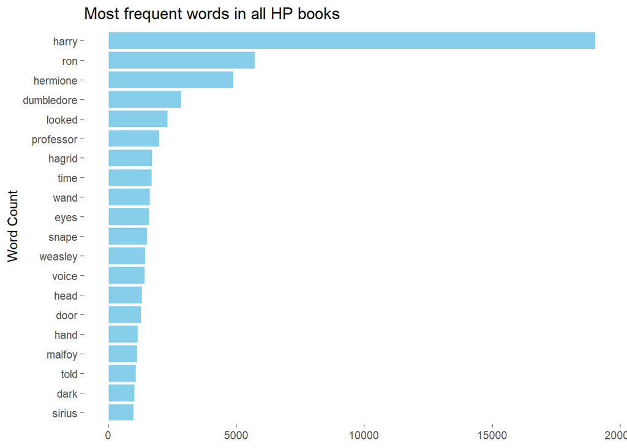

```r
  # Crear el gráfico con la palabra (x) y el número de menciones (y)
  ggplot(HP_all, aes(y = reorder(word, n), x = n)) +
  geom_col(fill = "skyblue", color = "white") +
  labs(
    title = "Most frequent words in all HP books",
    x = NULL,
    y = "Word Count"
  ) +
  theme_dark() +
  theme(panel.background = element_blank(),
        panel.grid = element_blank())
```

In Harry Potter’s books, the most repeated words are those referring to the main charaters like Harry, Ron, Hermione and Dumbledore who are the saviors of this story.

We also have professor, which is a word needed to show respect every time we hear about a teacher of the Academy. We also have wand referring to the magic of this world and dark, referring to the evil that comes.

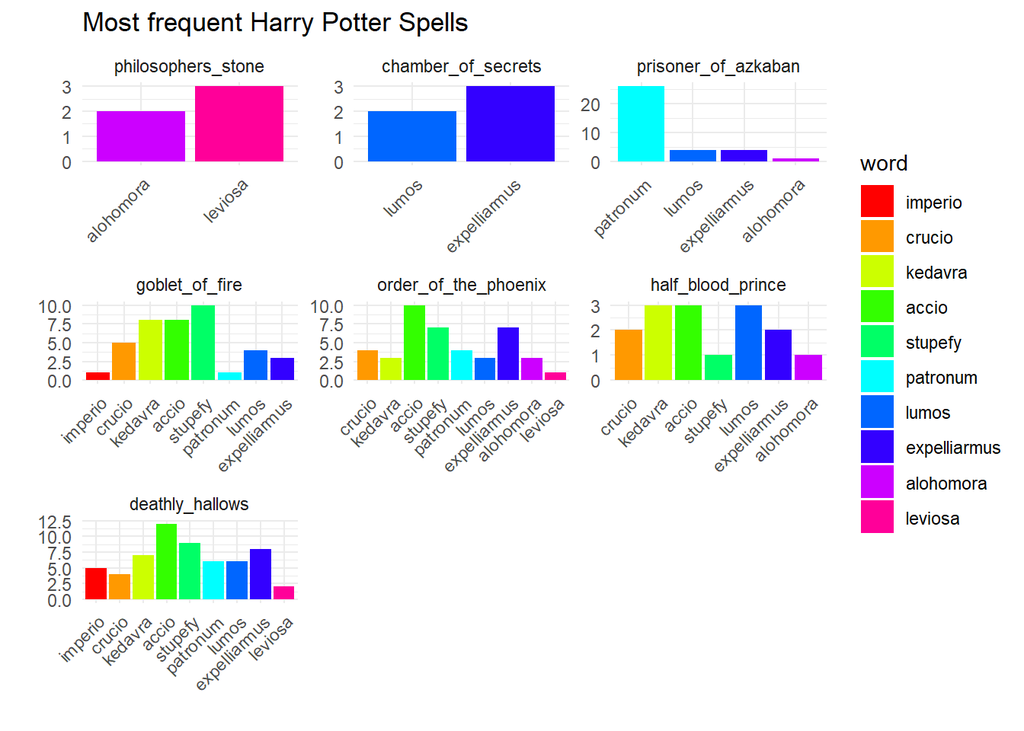

```r
hechizos_hp <- c('expelliarmus', 'alohomora', 'lumos', 'patronum','kedavra', 'leviosa', 'accio', 'stupefy', 'imperio', 'crucio')


hp_hechizos <- hp_words_processed %>%
  anti_join(stop_words) %>%
  filter(word %in% hechizos_hp) %>%
  count(book, word, sort = TRUE) %>%
  group_by(book) %>%
  slice_max(order_by = n, n = 20) %>%
  ungroup() %>%
  mutate(word = factor(word, levels = rev(unique(word)))) %>%
  ggplot(aes(x = word, y = n, fill = word)) +
  geom_col() +
  scale_fill_manual(values = rainbow(length(hechizos_hp))) +
  labs(
    title = "Most frequent Harry Potter Spells",
    x = "",
    y = ""
  ) +
  theme_minimal() +
  theme(
    axis.text.x = element_text(angle = 45, hjust = 1)
  ) +
  facet_wrap(~ book, scales = "free")
hp_hechizos
```

We can see huge differences between the first part of HR saga(the three first books), and the second part. Spells are a fundamental part in a magical world. In the first part, we observe that spells are inoffensive, funny, entertaining like alohomora or leviosa. However, in the second part, when the real action to save the magical world takes place. Spells to kill, knock out or to control minds are used.

```r
HP_counts <- hp_words_processed %>%
  anti_join(stop_words) %>%
  count(book, word) %>%
  group_by(book) %>%
  mutate(total_words = sum(n)) %>%
  ungroup() %>%
  group_by(book) %>%
  mutate(word_percent = n / total_words * 100) %>%
  slice_max(order_by = n, n = 15) %>%
  arrange(book, desc(word_percent))  # Ordenar los datos de mayor a menor por word_percent dentro de cada libro
```

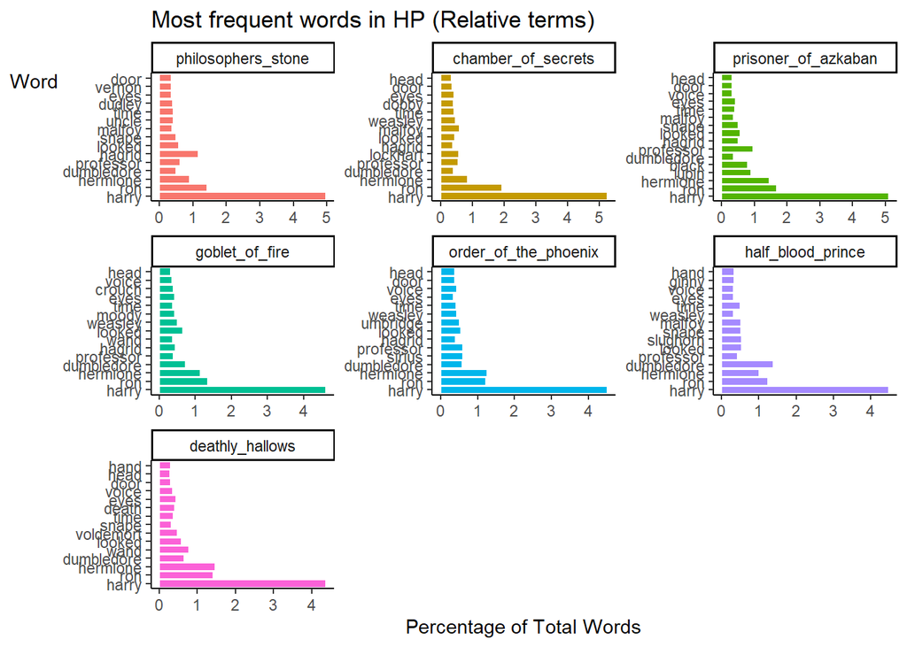

```r
ggplot(HP_counts, aes(x = reorder(word, -word_percent), y = word_percent, fill = book)) +
  geom_col(color = "white") +
  labs(
    title = "Most frequent words in HP (Relative terms)",
    x = "Word",
    y = "Percentage of Total Words"
  ) +
  facet_wrap(~ book, scales = "free") +
  coord_flip() +
  theme_classic() +
  theme(axis.title.y = element_text(angle = 0, hjust = 0.5), legend.position = "none")
```

In the end, Harry needed a community to defeat Voldemort. That is why we see more characters in the end. Harry is the chosen one, but he still needs the rest to succeed in this quest.

**Sentiment analysis**

**NRC for trust**

As we checked that our main hypothesis was wrong, and the community was more important in the story. We can explore words that express trust in HP. This a story of trust. To trust in Harry Potter and his company who will save the magical world threatened by Voldemort.

Professor(or teacher), mother, father, school, team, friend, brother are words frequently repeated because all those who Harry Potter is surrounded by. We have Ministry as well, which is an institution that has the duty to protect the magical world and at first, out characters will trust in it until it falls in the dark.

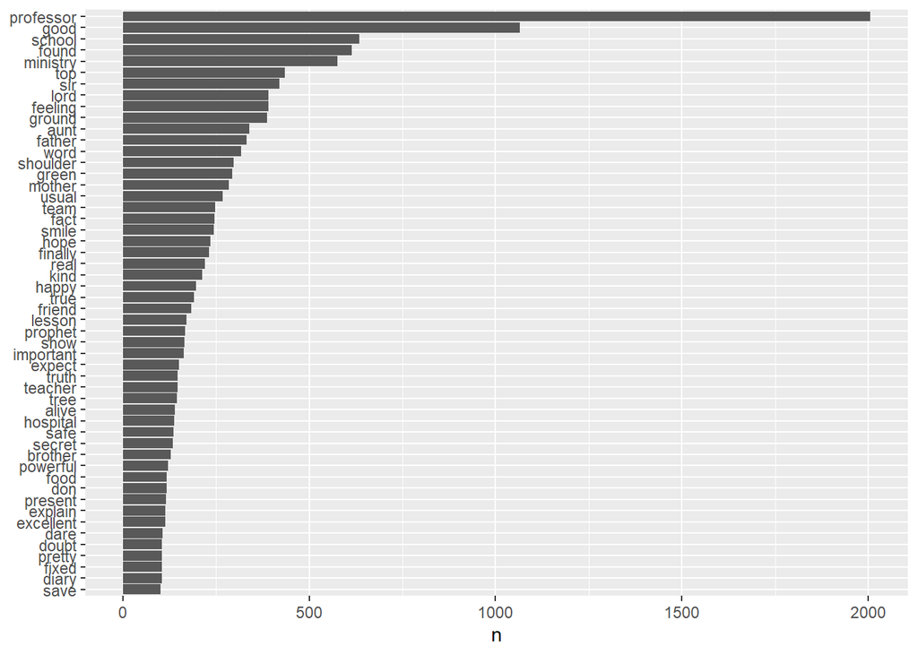

```r
#bien
nrc_trust <- get_sentiments("nrc") %>%
  filter(sentiment == "trust")

z <- hp_words_processed %>%
    #we combine both lists, NRC and Emma's words
    inner_join(nrc_trust) %>%
    #we count the mentions to see the most frequent words
    count(word, sort = TRUE) %>%
    #only words mentioned over 50 times in the novel
    filter(n > 100) %>%
    #we reorder words by number of mentions
    mutate(word = reorder(word, n)) |>
    #we create the plot with the word (x) and the number of mentions (y)
    ggplot(aes(x = n, y = word)) +
    geom_col() +
    labs(y = NULL)
z
```

**Bing**

Count and obtain the feeling of each chapter.

```r
#bien
k <- hp_words_processed %>%
  #find the sentiment for each word using bing
  inner_join(get_sentiments("bing")) %>%
  #divide each book in chunks of 80 lines
  count(book, chapter, sentiment) %>%
  #we write positive and negative in different columns
  pivot_wider(names_from = sentiment, values_from = n, values_fill = 0) %>%
  #we substract positive minus negative to find a net sentiment
  mutate(sentiment = positive - negative) |>
  filter(book == "deathly_hallows")
k
```

```
## # A tibble: 37 × 5
##    book            chapter negative positive sentiment
##    <fct>             <int>    <int>    <int>     <int>
##  1 deathly_hallows       1      117       86       -31
##  2 deathly_hallows       2      161      144       -17
##  3 deathly_hallows       3       94       93        -1
##  4 deathly_hallows       4      233      129      -104
##  5 deathly_hallows       5      268      143      -125
##  6 deathly_hallows       6      228      185       -43
##  7 deathly_hallows       7      167      181        14
##  8 deathly_hallows       8      177      197        20
##  9 deathly_hallows       9      165       79       -86
## 10 deathly_hallows      10      230      190       -40
## # ℹ 27 more rows
```

Bing positive and negative count

Like was the first positive word, but It can be misleading so it is a wise choose to put it in the stop_word list.

```r
custom_stop_words <- bind_rows(tibble(word = c("like", "looked"),
                                      lexicon = c("custom")),
                               stop_words)
count_w <- hp_words_processed %>%
  inner_join(get_sentiments("bing")) %>%
  anti_join(custom_stop_words) %>%  # Eliminar las palabras personalizadas que deseas omitir
  mutate(word = ifelse(word %in% c("magic", "magical"), "magic", word)) %>%
  mutate(word = ifelse(word %in% c("dead", "died", "death"), "death", word)) %>%
  mutate(word = ifelse(word %in% c("dark", "darkness"), "dark", word)) %>%
  count(word, sentiment, sort = TRUE) %>%
  ungroup()
```

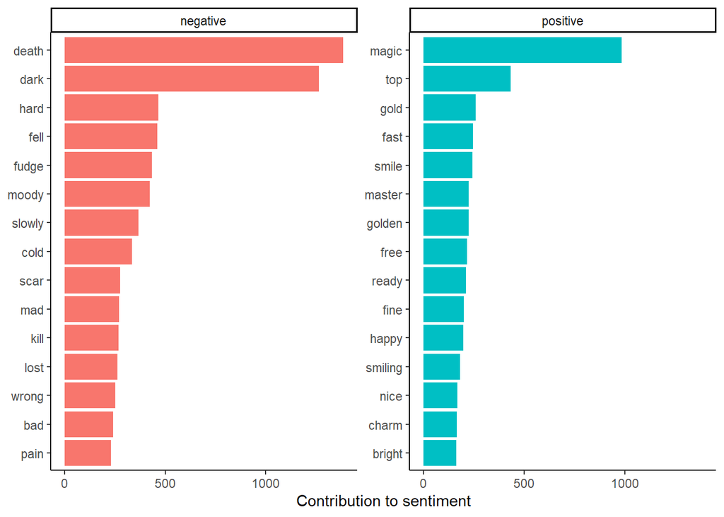

```r
hp_bing <- count_w %>%
  group_by(sentiment) %>%
  slice_max(n, n = 15) %>%
  ungroup() %>%
  mutate(word = reorder(word, n)) %>%
  ggplot(aes(n, word, fill = sentiment)) +
  geom_col(show.legend = FALSE) +
  facet_wrap(~sentiment, scales = "free_y") +
  labs(x = "Contribution to sentiment",
       y = NULL) +
    theme_classic()+
  # Drop panel grid lines
  theme(panel.grid = element_blank())

hp_bing
```

The main positive words are related to magic, which I unite them because are essentially the same, but used differently. We also have emotions like happy, charm…

The main negative feelings are correlated with the death(which I also united their variations) like the dark and pain Voldemort wants to bring to the magical world. We have also scar, but this is not a negative word, it is just to describe this characteristic of Harry. And finally, fudge can be related to the cooperation of the Ministry with Voldemort

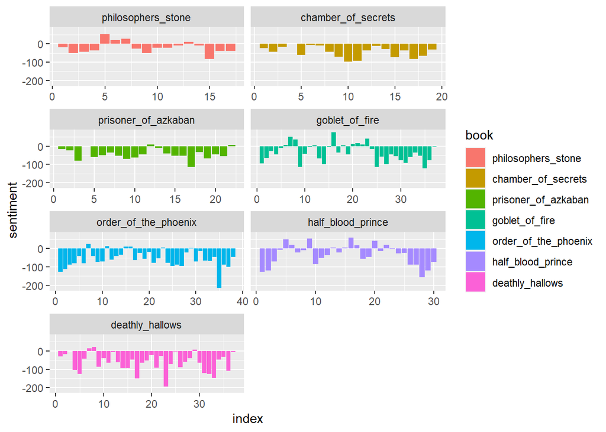

```r
c <- hp_words_processed %>%
  #find the sentiment for each word using bing
  inner_join(get_sentiments("bing")) %>%
  #divide each book in chunks of 80 lines
  count(book, index = chapter, sentiment) %>%
  #we write positive and negative in different columns
  pivot_wider(names_from = sentiment, values_from = n, values_fill = 0) %>%
  #we substract positive minus negative to find a net sentiment
  mutate(sentiment = positive - negative) |>
  ggplot(aes(index, sentiment, fill = book)) +
  geom_col(show.legend = TRUE) +
  facet_wrap(~book, ncol = 2, scales = "free_x")
c
```

Using this method, HP saga is still strongly negative in its story,

**afinn method**

```r
afinn_hp <- hp_words %>%
  inner_join(get_sentiments("afinn")) %>%
  group_by(index = book) %>%
  summarise(sentiment = sum(value)) %>%
  mutate(method = "AFINN")
afinn_hp
```

```
## # A tibble: 7 × 3
##   index                sentiment method
##   <fct>                    <dbl> <chr>
## 1 philosophers_stone         224 AFINN
## 2 chamber_of_secrets        -188 AFINN
## 3 prisoner_of_azkaban       -340 AFINN
## 4 goblet_of_fire            -169 AFINN
## 5 order_of_the_phoenix      -717 AFINN
## 6 half_blood_prince          330 AFINN
## 7 deathly_hallows          -2263 AFINN
```

To sum up, Harry Potter is a saga with a great negative charge, despite the magic which is commonly associated with luck, future and goodness.

**TF-IDF**

In this part we are going to explore about *TF*(term frequency), which is the repetition of a word in an absolute value. Furthermore, we have *IDF*(Inverse document frequency) which in relative values it measures a repeated word in comparison with the rest of the collection . Finally, *TF-IDF* is a metric that allow us a real value of a word in a document.

In order to create a TF and a IDF we need the total number of repetition of each word in each book, and the total number of word of each book.

Remember that for TF-IDF, we do not need to remove stop words because they are naturally remove.

```r
#Total repetition of each word by book
hp_words_count <- hp_words_processed |>
    count(book, word, sort = TRUE)
hp_words_count
```

```
## # A tibble: 67,836 × 3
##    book                 word      n
##    <fct>                <chr> <int>
##  1 order_of_the_phoenix the   11742
##  2 deathly_hallows      the   10335
##  3 goblet_of_fire       the    9305
##  4 half_blood_prince    the    7508
##  5 order_of_the_phoenix to     6518
##  6 order_of_the_phoenix and    6189
##  7 deathly_hallows      and    5510
##  8 order_of_the_phoenix of     5332
##  9 prisoner_of_azkaban  the    4990
## 10 goblet_of_fire       and    4959
## # ℹ 67,826 more rows
```

```r
#Total words by book
hp_total_words <- hp_words_count |>
  #we group by books to sum all the totals in the n column of book_words
  group_by(book) |>
  #we create a column called total with the total of words by book
  summarize(total = sum(n))
hp_total_words
```

```
## # A tibble: 7 × 2
##   book                  total
##   <fct>                 <int>
## 1 philosophers_stone    77875
## 2 chamber_of_secrets    85401
## 3 prisoner_of_azkaban  105275
## 4 goblet_of_fire       191882
## 5 order_of_the_phoenix 258789
## 6 half_blood_prince    171287
## 7 deathly_hallows      198918
```

```r
#We do a left_join to have them in a single data frame and create the TF
hp_book_words <- left_join(hp_words_count, hp_total_words) |>
                    mutate(term_frequency = n/total)
```

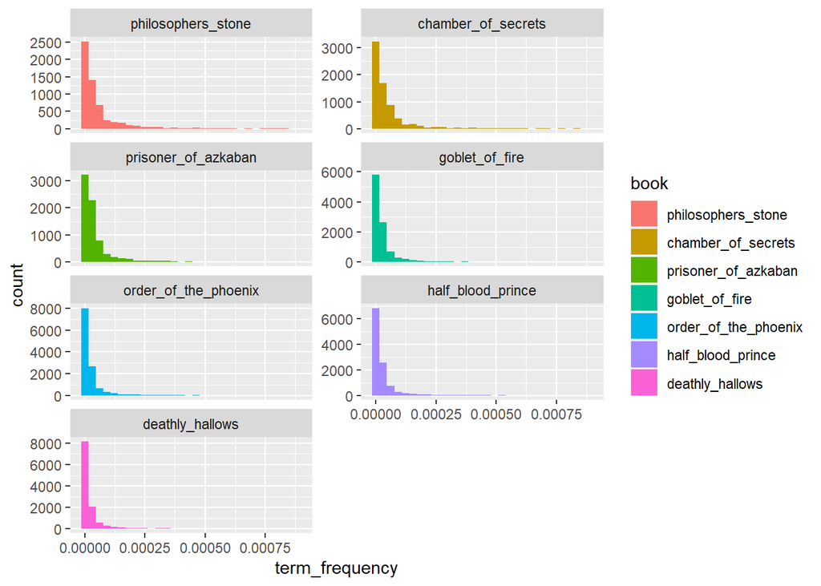

```r
#we calculate the distribution and put it in the x axis, filling by book
ggplot(hp_book_words, aes(term_frequency, fill = book)) +
  #we create the bars histogram
  geom_histogram(show.legend = TRUE) +
  #we set the limit for the term frequency in the x axis
  xlim(NA, 0.0009) +
  #plot settings
  facet_wrap(~book, ncol = 2, scales = "free_y")
```

This is the well-known **long tail distribution**. There is a similar distribution for all books: most words have very low frequencies (on the left) and a few words have very high frequencies (on the right).

**Zipf’s law in Harry Potter**

This law address that the frequency of a word appearance in a text is inversely proportional to its rank. Each word has a unique rank, *the most repeated word has rank 1 and successively*. Consequently, the lower the term frequency, it will has a higher rank.

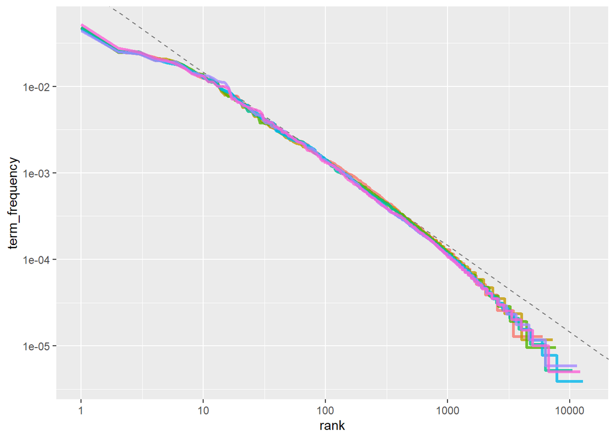

```r
hp_freq_by_rank <- hp_book_words |>
  group_by(book) |>
  #we create the column for the rank with row_number
  mutate(rank = row_number()) |>
  ungroup()

  ggplot(hp_freq_by_rank, aes(rank, term_frequency, color = book)) +
  #we add a line in the plot with the two coefficients we have found
  geom_abline(intercept = -0.84, slope = -1,
              color = "gray50", linetype = 2) +
  geom_line(size = 1.1, alpha = 0.8, show.legend = FALSE) +
  scale_x_log10() +
  scale_y_log10()
```

```r
hp_freq_by_rank
```

```
## # A tibble: 67,836 × 6
##    book                 word      n  total term_frequency  rank
##    <fct>                <chr> <int>  <int>          <dbl> <int>
##  1 order_of_the_phoenix the   11742 258789         0.0454     1
##  2 deathly_hallows      the   10335 198918         0.0520     1
##  3 goblet_of_fire       the    9305 191882         0.0485     1
##  4 half_blood_prince    the    7508 171287         0.0438     1
##  5 order_of_the_phoenix to     6518 258789         0.0252     2
##  6 order_of_the_phoenix and    6189 258789         0.0239     3
##  7 deathly_hallows      and    5510 198918         0.0277     2
##  8 order_of_the_phoenix of     5332 258789         0.0206     4
##  9 prisoner_of_azkaban  the    4990 105275         0.0474     1
## 10 goblet_of_fire       and    4959 191882         0.0258     2
## # ℹ 67,826 more rows
```

We can divide it in three to see deviations.

```r
rank_subset <- hp_freq_by_rank %>%
  filter(rank < 500,
         rank > 10)

#we use the linear model function to find numeric coefficients of relationship between tf and rank
lm(log10(term_frequency) ~ log10(rank), data = rank_subset)
```

```
##
## Call:
## lm(formula = log10(term_frequency) ~ log10(rank), data = rank_subset)
##
## Coefficients:
## (Intercept)  log10(rank)
##     -0.8431      -1.0121
```

```r
HP_book_tf_idf <- hp_book_words %>%
  bind_tf_idf(word, book, n) |>
  select(-total) %>%
  arrange(desc(tf_idf))

word_to_remove <- "c"

# Filtering out the rows containing the word to remove
HP_book_tf_idf_filtered <- HP_book_tf_idf %>%
  filter(word != word_to_remove)

HP_book_tf_idf_filtered
```

```
## # A tibble: 67,831 × 7
##    book                 word            n term_frequency       tf   idf   tf_idf
##    <fct>                <chr>       <int>          <dbl>    <dbl> <dbl>    <dbl>
##  1 half_blood_prince    slughorn      335       0.00196  0.00196  1.25  0.00245
##  2 order_of_the_phoenix umbridge      496       0.00192  0.00192  0.847 0.00162
##  3 goblet_of_fire       bagman        208       0.00108  0.00108  1.25  0.00136
##  4 chamber_of_secrets   lockhart      197       0.00231  0.00231  0.560 0.00129
##  5 prisoner_of_azkaban  lupin         369       0.00351  0.00351  0.336 0.00118
##  6 goblet_of_fire       winky         145       0.000756 0.000756 1.25  0.000947
##  7 goblet_of_fire       champions      84       0.000438 0.000438 1.95  0.000852
##  8 deathly_hallows      xenophilius    79       0.000397 0.000397 1.95  0.000773
##  9 half_blood_prince    mclaggen       65       0.000379 0.000379 1.95  0.000738
## 10 deathly_hallows      griphook      117       0.000588 0.000588 1.25  0.000737
## # ℹ 67,821 more rows
```

Using this code, we finally obtain tf-idf. In the book deathly hallows “C” appears. We have checked using this code (grep(“^c$", hp_words$word)) in which situations c is used, and it was just an error. Therefore, we remove it in order to not interfere in our analysis.

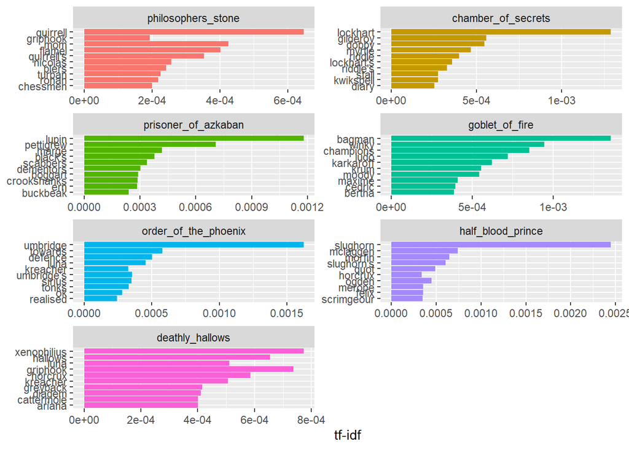

```r
HP_book_tf_idf_filtered %>%
  group_by(book) %>%
  #choose maximum number of words
  slice_max(tf_idf, n = 10) %>%
  ungroup() %>%
  ggplot(aes(tf_idf, fct_reorder(word, tf_idf), fill = book)) +
  geom_col(show.legend = FALSE) +
  facet_wrap(~book, ncol = 2, scales = "free") +
  labs(x = "tf-idf", y = NULL)
```

Meassuring tf-idf show us comparison between texts. One word can be relevant in a document, very representative, but if it occurs a lot in all the books, it will not be distinctive of one.

In our case, in the film Goblet of fire there are some distinctive words like cedric or champions because in this book occurs the championship in which Cedric dies by the hands of Voldemort.

We can see that characters are very meaningful again because in each book there are distinctive characters, for instance Dobby in the Chamber of Secrets or Luna in Order of Phoenix

Finally, we have Horcrux, which is a key word and we could say distinctive from the last to books because in that moment they realized Voldemort only can be defeated by destroying his pieces of soul contained in the Horcrux.

**N-grams**

In this case we will use 2-grams, so we will se which pair of words are repeated the most. With this code, we prepare the books to be analized by 2-grams.

```r
# Lista de los títulos de los libros de Harry Potter
hp_books <- c(
  "philosophers_stone",
  "chamber_of_secrets",
  "prisoner_of_azkaban",
  "goblet_of_fire",
  "order_of_the_phoenix",
  "half_blood_prince",
  "deathly_hallows"
)

# Lista de los textos de los libros de Harry Potter
hp_textos <- list(
  philosophers_stone,
  chamber_of_secrets,
  prisoner_of_azkaban,
  goblet_of_fire,
  order_of_the_phoenix,
  half_blood_prince,
  deathly_hallows
)

# Combinar los textos en un solo marco de datos y tokenizar en bigramas
hp_words_2_grams <- hp_textos %>%
  # Nombrar cada elemento de la lista
  set_names(hp_books) %>%
  # Convertir cada libro en un marco de datos y combinarlos en un solo marco de datos
  map_df(as_tibble, .id = "book") %>%
  mutate(book = factor(book, levels = hp_books)) %>%
  drop_na(value) %>%
  # Crear una columna de identificación de capítulo
  group_by(book)  %>%
  mutate(chapter = row_number(book))  %>%
  ungroup()  %>%
  # Tokenizar el marco de datos en bigramas
  unnest_tokens(bigram, value, token = "ngrams", n = 2) |>
  select(-chapter)

hp_words_2_grams <- hp_textos %>%
  # Nombrar cada elemento de la lista
  set_names(hp_books) %>%
  # Convertir cada libro en un marco de datos y combinarlos en un solo marco de datos
  map_df(as_tibble, .id = "book") %>%
  mutate(book = factor(book, levels = hp_books)) %>%
  drop_na(value) %>%
  # Crear una columna de identificación de capítulo
  group_by(book)  %>%
  mutate(chapter = row_number(book))  %>%
  ungroup()  %>%
  # Tokenizar el marco de datos en bigramas
  unnest_tokens(bigram, value, token = "ngrams", n = 2) %>%
  select(-chapter) %>%
  # Añadir nuevamente la columna book
  mutate(book = factor(book, levels = hp_books))
```

```r
hp_words_2_grams_final <- hp_words_2_grams |>
  count(bigram, sort = TRUE) |>
  #we separate each bigram in two columns, word1 and word2
  separate(bigram, c("word1", "word2"), sep = " ") |>
  #we filter all words included in the word column in stop_words
  filter(!word1 %in% custom_stop_words$word) |>
  filter(!word2 %in% custom_stop_words$word) |>
  unite(bigram, word1, word2, sep = " ")


head(hp_words_2_grams_final)
```

```
## # A tibble: 6 × 2
##   bigram                   n
##   <chr>                <int>
## 1 professor mcgonagall   578
## 2 uncle vernon           386
## 3 harry potter           351
## 4 death eaters           346
## 5 harry ron              302
## 6 aunt petunia           206
```

Professor Mcgonagall is the most 2-grams used. We see that Dumbeldore is more frequent than Mcgonagall, and he is the director of Hogwarts but he is so close to the group of Potter that they no longer say Professor. Harry Potter is an obvoius 2-grams. Harry and Ron is very curious. They both get into troubles many time, so it is a way to point out them. Another conclusion is that this duo is more close that harry-hermione or hermnione-ron.

**Correlations**

Lets’s now work with correlations and we will see in the first book which was the story about.

```r
hp_section_words <- hp_words_processed %>%
  filter(book == "philosophers_stone") %>%
  filter(!word %in% custom_stop_words$word)

hp_section_words
```

```
## # A tibble: 28,416 × 3
##    book               chapter word
##    <fct>                <int> <chr>
##  1 philosophers_stone       1 boy
##  2 philosophers_stone       1 lived
##  3 philosophers_stone       1 dursley
##  4 philosophers_stone       1 privet
##  5 philosophers_stone       1 drive
##  6 philosophers_stone       1 proud
##  7 philosophers_stone       1 perfectly
##  8 philosophers_stone       1 normal
##  9 philosophers_stone       1 people
## 10 philosophers_stone       1 expect
## # ℹ 28,406 more rows
```

Phi coefficient measures **how likely it is that two words appear together taking into account the probability for each word of appearing alone**.

```r
word_cors <- hp_section_words %>%
  group_by(word) %>%
  filter(n() >= 20) %>%
  pairwise_cor(word, chapter, sort = TRUE)

word_cors
```

```
## # A tibble: 59,780 × 3
##    item1     item2  correlation
##    <chr>     <chr>        <dbl>
##  1 fell      stared           1
##  2 gasped    stared           1
##  3 floor     lot              1
##  4 stared    fell             1
##  5 gasped    fell             1
##  6 lot       floor            1
##  7 silver    legs             1
##  8 pulled    words            1
##  9 professor words            1
## 10 feet      words            1
## # ℹ 59,770 more rows
```

To explore about the story, we will filter by the main two houses of Hogwarts: Gryffindor and Slytherin.

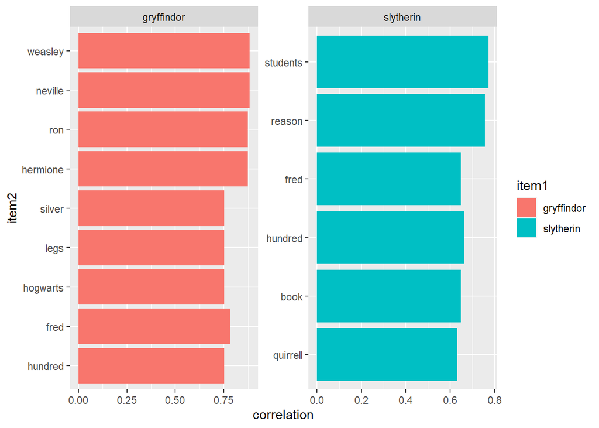

```r
word_cors %>%
  #we define a vector for 4 words
  filter(item1 %in% c("gryffindor", "slytherin")) |>
  #we group by item1
  group_by(item1) %>%
  #we use the first 6 most correlated
  slice_max(correlation, n = 6) %>%
  ungroup() %>%
  #we reorder item2 regarding its correlation
  mutate(item2 = reorder(item2, correlation)) %>%
  #we plot
  ggplot(aes(item2, correlation, fill=item1)) +
  geom_bar(stat = "identity") +
  facet_wrap(~ item1, scales = "free") +
  coord_flip()
```

And after this, we will plot a network to work on the story!

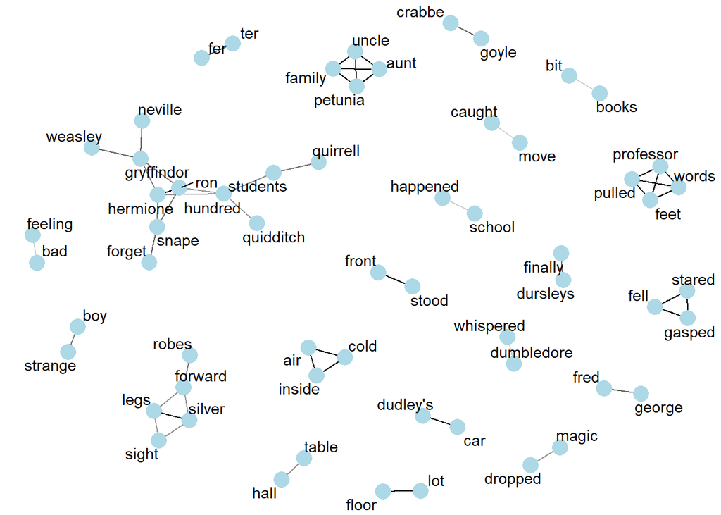

```r
word_cors %>%
  filter(correlation > 0.80) %>%
  ggraph(layout = "fr") +
  geom_edge_link(aes(edge_alpha = correlation), show.legend = FALSE) +
  geom_node_point(color = "lightblue", size = 5) +
  geom_node_text(aes(label = name), repel = TRUE) +
  theme_void()
```

I have to remember that this stories are told following the correlations of words Gryffindor and Slytherin.

In the beginning of the story, we were introduced to Potter’s family, which is petunia(aunt), his uncle, and we have the word family correlated because them are the only family left.

This plot show us the quidditch match in which you obtain points(hundred), there are just students of Hogwarts playing, one of the team is Gryffindor, and characters that this section involves are Ron and Hermione who see professor Snape doing a spell, and they thought he was doing trumps moving Harry Potter’s broom. Finally, they discover the real guilty, professor Quirrell. Follower of Voldemort’s creed and he had the aim of taking Harry Potter’s life.

**Conclusions**

In conclusion, throughout this project we have seen that Text Mining is a powerful and versatile tool that boost our power to explain texts and reinforce our hypothesis. We explained how the horror grew in the second part of the saga, which will no longer a child story. Furthermore, we can describe the main parts of each book thanks to correlations